# Statistical Inference in Biology Assignment 2

201900700284 Yang Sihao

2021/3/29

# 1、The Null and alternative hypotheses

Null hypotheses: time required to drink a glass of beer is not related to the shape of the glass Alternative hypotheses: time required to drink a glass of beer is related to the shape of the glass

# 2、Sample data

1、The data is continuous because the data can take any value within a certain interval. 2、Load the data

```r
beer.df <- read.csv("beer.csv", stringsAsFactors = T)
beer.df
```

```
##    glassShape drinkingTime
## 1    straight        11.63
## 2    straight        10.37
## 3    straight        17.89
## 4    straight         6.96
## 5    straight        20.40
## 6    straight        20.64
## 7    straight         9.26
## 8    straight        18.11
## 9    straight        10.33
## 10   straight        23.54
## 11     curved         7.46
## 12     curved         9.28
## 13     curved         8.90
## 14     curved         6.73
## 15     curved         8.25
## 16     curved         6.16
## 17     curved        13.09
## 18     curved         2.10
## 19     curved         6.37
```

3、Calculate the mean、minimum、maximum

```r
levels(beer.df$glassShape)
```

```
## [1] "curved"   "straight"
```

```r
nlevels(beer.df$glassShape)
```

```
## [1] 2
```

```r
beer.mean<-mean(beer.df$drinkingTime)
```

The mean is approximately 11.45.

```r
min(beer.df$drinkingTime)
```

```
## [1] 2.1
```

```r
max(beer.df$drinkingTime)
```

```
## [1] 23.54
```

The minimum is 2.1 , the maximum is 23.54.

```r
length(beer.df$drinkingTime)
```

```
## [1] 19
```

```r
straight<-beer.df[beer.df$glassShape=="straight","drinkingTime"]
curved<-beer.df[beer.df$glassShape=="curved","drinkingTime"]
```

There are 19 observations conducted, 10 for straight, 9 for curved. The measure was that 19 participants drink the glass of beer in minutes, so the sample size is 19.

# 3、Make a box plot presenting the data.

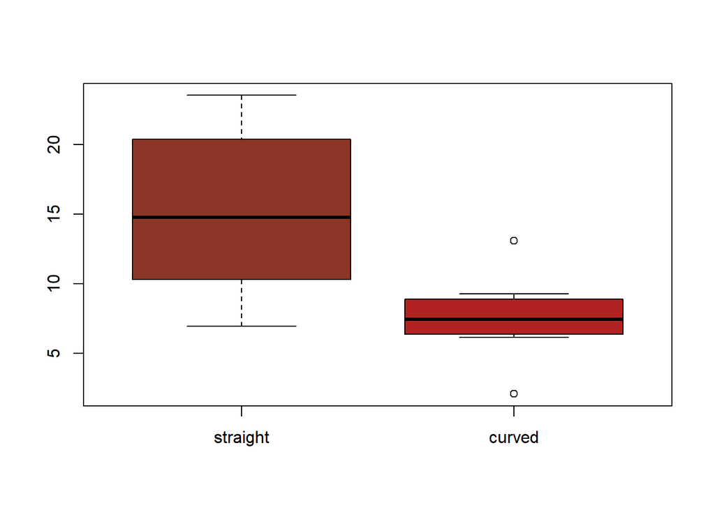

```r
boxplot(straight,curved,col = c("tomato4","firebrick"),names = c("straight","curved"))
```

The shape of glasses could impact the time of drinking from this box plot.

# 4、The statistical test

I’m going to use the t-test because the t-test is mainly used for normal distributions where the sample size is small and the population standard deviation σ is unknown. This problem is to test whether the two samples are significant enough to determine the relationship between the drinking time and the shape of the glass. I will use the t.test() function to perform the test.

# 5、Perform the test.

```r
beer.t<-t.test(straight,curved,alternative = "two.sided",var.equal = T)
beer.t
```

```
##
##  Two Sample t-test
##
## data:  straight and curved
## t = 3.3977, df = 17, p-value = 0.003425
## alternative hypothesis: true difference in means is not equal to 0
## 95 percent confidence interval:
##   2.774455 11.864878
## sample estimates:
## mean of x mean of y
## 14.913000  7.593333
```

Given the observations there is a statistically significant difference between means of the two samples. The p-value is 0.003425 is lower than the level of significance, the α (0.05), so reject the Null hypotheses and accept the Alternative hypotheses, time required to drink a glass of beer is related to the shape of the glass.

# 6、Results of the test

The calculated t-statistic is 3.3977. The Calculated p-values is 0.003425. The 95 percent confidence interval is from 2.774455 to 11.864878.

# 7、Conclusion

I initially created two vectors of the curved and straight, I performed a box plot of the two groups to see the direction of the change. I then analyzed the difference between the curved and straight using a two sample t-test. The statistical test: Two sided t-test confirmed provided statistical support for the difference between time required to drink a glass of beer between the curved and the straight glasses. The calculated p-value < 0.005 is lesser than the significance level α=0.05 providing a strong statistical support for rejection of the Null hypothesis. Given the data we can reject the Null hypothesis and accept the alternative hypothesis: time required to drink a glass of beer is related to the shape of the glass. I’d like to point out that the observation is too small to get an good result, to avoid this issue we can measure more than 19 participants.